# Quantitative Genetics – PCB6555

Genotype x Environment Interactions

Felipe Ferrão and Marcio Resende Jr

University of Florida – November, 2020

**Recapping:**

- We initially expressed genotypic means, breeding value and genotypic variance as a function of allele frequencies and genotypic values and showed that we are able to distangle the causal variance components, using information from resemblance between relaties
- Mating desings, such as factorials and diallels, produces full-sibs families and therefore an alternative to estimate both addtive and dominance effects
- The use o multivariate analysis, combining to pedigree information allows us to rank genotypes and understand the correlation between traits

**Plan for today:**

- Expand the initial mixed model presented in the multi-trait class for GxE analysis
- GxE analysis using regression methods in a wheat data set
- MET analysis via mixed model using a pinus data set. Similar pace that we used in the multi-trait analysis

# 1 Theory

## 1.1 Introduction

Genotype-by-environment interaction (GEI) is an important phenomenon in breeding. The success of any breeding program depends on the ability to identify genotypes with superior performance. Here, by environment, we mean a specific condiction (or geographical location) in which a genotype developed (eg, sites, farmers, years, seasons). To achieve this aim, it is necessary to have an understanding of the factors leading to a good phenotype.

Some scenarios that can occur when comparing the performances of pairs of genotypes across environments are:

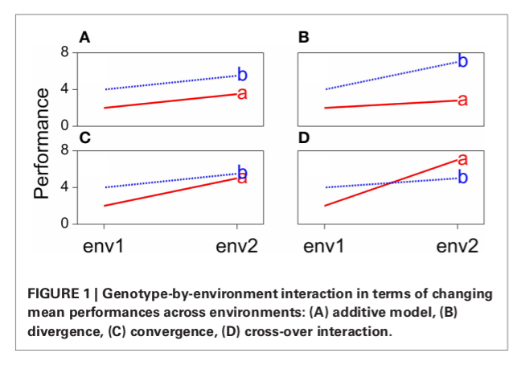

GxE representation from Malosetti et al., (2013)

1. No GxE – the genotype and the environment behave additively
2. Divergence
3. Convergence
4. Crossover interaction – most important, imply that the choice of the best genotype is determined by the environment.

GxE is traditionally presented in terms of the relative difference between genotypic means. However, GxE can also be regarded in terms of heterogeneity of genetic variance and covariance. As a consequence, the magnitude of the genetic variance as observed within individual environments will change from one environment to the next. Often, the genetic variance tends to be larger in better environments than in poorer environments,although the opposite can be observed as well (Malosetti et al., 2013).

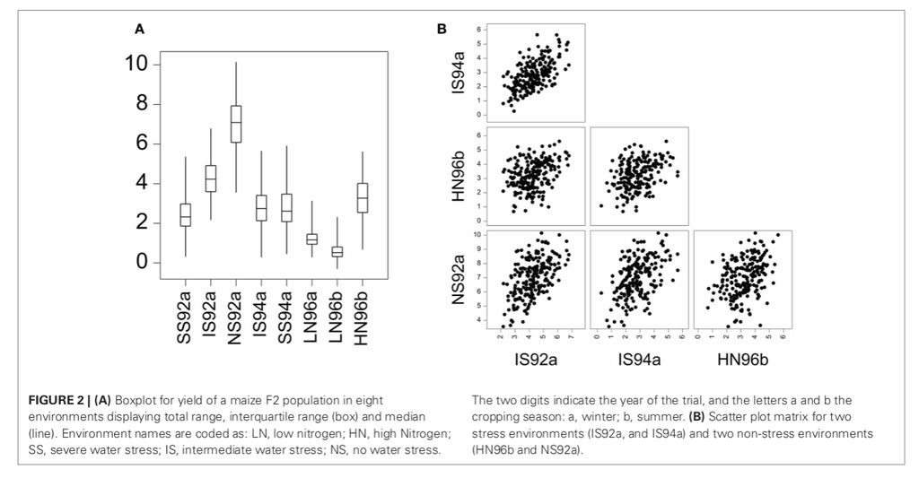

GxE represented as heterogeneity of genetic variance and covariance – Malosetti et al., (2013)

In multi environmental trials (MET) a set of genotypes are raised in a number of environments, with some specific objectives:

- Compare genotypes across a range of environments
- Identify superior genotypes for subsets of the testing environments
- Estimate genetic correlations between environments

## 1.2 Statistical Aspects

### 1.2.1 Two-way ANOVA

A natural formulation for a GxE problem is in form of a two-way classification with interaction, with genotypes and environments as main effects, in an analysis of variance (ANOVA).

$$y_{ijk} = \mu + g_i + e_j + ge_{ij} + \epsilon_{ijk}$$

- $y_{ijk}$ = denote the k-th record for the i-th genotype in the j-th environment
- $g_{i}$ and $e_j$ = fixed additive effects of genotype i and environment j
- $ge_{ij}$ = fixed interaction effect
- $\epsilon_{ijk}$ = random residual term, where: $\epsilon_{ijk} \sim N(0,I\sigma^2_e)$

Such two-way ANOVA model implies estimation of as many parameters as there are GxE combinations, something that is not desirable in the interest of parsimony. Another limitation of the model is that it is not possible to estimate the genotypic performance in environments that are not included in the trial.

**Advantages**

- Straightforward implementation

**Drawbacks**

- The use of classical ANOVA could tell us something about the amount of variation due to genotypic main effects in relation to the interaction term, by comparing sums of squares or mean squares, but it does not bring much progress toward understanding GEI.

### 1.2.2 Finlay and Wilkinson Regression

A more attractive alternative is to extend the additive model by incorporating terms that explain as much as possible of the interaction. To this end, a popular method in the plant breeding literature uses regression on the mean model. [Finlay and Wilkinson (1963)](http://www.publish.csiro.au/cp/AR9630742) regression describes GxE interaction as a regression line on the environmental quality.

The Finlay–Wilkinson regression requires regressing the observed phenotypes of the line on environment effects. In the absence of explicit environmental information, the biological quality of an environment can be reflected in the average performance of all genotypes in that environment. Good environments will have a high average genotypic performance, and bad environments will have a low average genotypic performance. Thus, the GxE part is then described by a regression slopes on the environmental quality, as:

$$y_{ijk} = \mu + g_i + \hat{h}_j + b_i\hat{h}_j + \epsilon_{ijk}$$

In short, regression on the mean model describes GxE in terms of parameters that can be given some biological meaning, including to central concepts of **adaptability** and **stability** – or in another words, **broad** and **specific** adaptation.

**Advantages**

- Straightforward implementation
- Easy interpretation with some biological meaning

**Drawbacks**

- Suffers from the fact that the environmental characterization is based on a single dimension.
- Environmental quality can be hard to summarize within a single explanatory variable and hence a substantial amount of GxE can remain unexplained.

### 1.2.3 Mixed Models: modeling genetic variances and covariances

#### 1.2.3.1 Theory

Interaction can be regarded both in terms of differential mean responses across environments and in terms of **heterogeneity of genetic variation and covariation between environments**. While ANOVA and regression models are primarily focus on modeling the mean response, mixed models focuses on the modeling of GxE in terms of heterogeneity of variances and covariances. It is analogous to the multi-trait methods.

Mixed model approach will allow us to relax assumptions of homogeneous genetic and residuals variances across environments. To this end, GxE interaction via mixed model formulation may not be immediately obvious at the first glance, as it combines the genotype and genotype-by-environment factors into a single model factor (compound term) of genotype nested within environment. Below, there is an example of a linear mixed model for GxE analysis:

**Explicit interaction model**

$$y_{ijk} = \mu + E_i + \underline{G_{j}} + \underline{GE_{ij}} + \underline{e_{ijk}}$$

**Implicit interaction model**

$$y_{ijk} = \mu + E_i + \underline{G(E)_{ij}} + \underline{e_{ijk}}$$

$$G(E)_{ij} \sim N(0, G_0\otimes A)$$
$$e_{ijk} \sim N(0, I \otimes R_0)$$

In this model, we have a random genetic main effect that changes between groups of environments and that has a covariance matrix $G_0$ that consists of group specific genetic variances, with $\sigma^2$ for environment j, on the diagonals, and pairwise-specific genetic covariances, with between groups, on the off-diagonals. For example, considering two environments and information from pedigree:

$$G = \begin{bmatrix} {\sigma^2_{a_1}} & {\sigma^2_{a_{12}}} \\
{\sigma^2_{a_{12}}} & {\sigma^2_{a_{2}}} \end{bmatrix} \otimes A;
R = I \otimes \begin{bmatrix} {\sigma^2_{e_1}} & {\sigma^2_{e_{12}}} \\
{\sigma^2_{e_{12}}} & {\sigma^2_{e_{2}}} \end{bmatrix}$$

**Important**

- Explicit and implicit interaction model are the same model, depending of the $\Sigma_g$ var-cov structure.
- Mixed model gives an important flexibility to test different var-cov structures for the $\Sigma_g$ term.

#### 1.2.3.2 Bonus

**Example of var-cov structure commonly investigated in GxE studies**

For the genetic random effect, different matrix structures of variance and covariance can be tested. These structures are shown schematically in the next table. Herein, two important points deserve mention:

1. Each structure assumes different assumptions about the heterogeneity of variance and, consequently, about the magnitude of the interaction
2. The structures present different degrees of complexity, which can be represented by the number of parameters to be estimated.

[output not shown]

# 2 Practice

- FW using a wheat data set
- Mixed model using a pinus data set

## 2.1 Finlay and Wilkinson (FW) Regression

### 2.1.1 Wheat data set

- Could be easily implemented using the `lm` function in R.
- `FW` R package.
- [Li and de los Campos, 2016](https://www.g3journal.org/content/6/3/589)
- Descriptions:
  - 599 wheat lines from CIMMYT’s Global Wheat Program evaluated for grain yield (average of two plot records) in four environments.
  - The data set becomes available in the R package.

### 2.1.2 Defining the model

$$y_{ijk} = \mu + g_i + \hat{h}_j + b_i\hat{h}_j + \epsilon_{ijk}$$

- $g_i$ and $h_j$ = the main effect of ith variety and the main effect of the jth environment
- $\epsilon_{ijk}$ = error term, assumed to be IID
- $b_i$ = slope, is the change of expected variety performance per unit change of the environment effect.

The standard implementation of Finlay–Wilkinson regression is a two-step procedure whereas in the first step environmental sample means are computed and in the second step intercepts and slopes of each line are estimated by regressing, within line, the performance of each line on the estimated environmental means.

**Codes**

```r
#####################
# FW Regression
#####################
library(FW)
data("wheat")

str(wheat.Y) # data set

# Model
lm1 = FW(y = wheat.Y$y,     # phenotypic data
         VAR = wheat.Y$VAR,  # genotype
         ENV = wheat.Y$ENV,  # env
         method="OLS")
plot(lm1)

# Env load
lm1$h # Indirect value of the env

# Slope
beta = data.frame(lm1$b)
beta%>%
  arrange(desc(lm1.b)) %>%
  head(.)

# Mean
genotype = data.frame(lm1$g)
genotype%>%
  arrange(desc(lm1.g)) %>%
  head(.)

par(mfrow=c(2,2))
plot(lm1, plotVAR = c("424673","424689","294614", "342284", "294724"),
     ylim = c(-1,7), main= "Adaptability to good env")
plot(lm1, plotVAR = c("1563726","1081265","377165", "368747", "1082612"),
     ylim = c(-1,7), main = "High mean genotypic performance")
plot(lm1, plotVAR = c("4057142","4069854","3827770", "3863169", "3827759"),
     ylim = c(-1,7), main = "Oppositive adaptability")
plot(lm1, plotVAR = c("89491","217743","295091", "770285", "443483"),
     ylim = c(-1,7), main = "Stability")

# Questions:
# i) What is the importance to combine adaptability and high performance?
# ii) What is the importance to select stable genotypes?
# iii) Can we use the FW for grouping environments?
```

## 2.2 Mixed Model and Multi Environmental Trial (MET)

### 2.2.1 Pinus data set

| Effect | Observation | Levels |
| --- | --- | --- |
| site | location of the progeny test | 12 |
| block | replication number | 20 |
| female | GCA effect | 70 |
| height | response variable | numeric |

### 2.2.2 Defining the model

**Traditional GxE Model – factorial model**

$$y_{ijk} = \mu + L_i + \underline{B(L)_{ij}} + \underline{G_k} + \underline{GL_{ik}} + \underline{e_{ijk}}$$

- $\mu$ is the overall mean;
- $L_i$ = fixed effect of location i
- $B(L)_{ij}$ = random effect of block j nested within location i
- $G_k$ = random effect of female k (GCA effect), where: $g \sim N(0,I\sigma^2_g)$
- $GL_{ik}$ = random effect of interaction between genotype k and location i, where $ge \sim N(0,I\sigma^2_{ge})$
- $e_{ijk}$ = random effect error, distributed as: $e_{ijk} \sim N(0, I\sigma^2_e)$

**Codes**

In this demo we will test a series of mixed models with different variance and covariance matrix structures for the interaction and residual terms. From `m0` to `m5`, we are increasing the complexity of the model by estimating more parameters and assuming more complex var-cov structures for the genetic and residual term.

1. `m0`: analyze each site separately to obtain variances

$$y_{ijk} = \mu + \underline{B_{j}} + \underline{G_k} + \underline{e_{ijk}}$$

2. `m1`: cross-classified ANOVA model. Traditional genotype-by-environment model, also called as explicit interaction model. Variance structures for random effects, including residual, are scaled identical and independent.

$$y_{ijk} = \mu + L_i + \underline{B(L)_{ij}} + \underline{G_k} + \underline{GL_{ik}} + \underline{e_{ijk}}$$
$$Var(Y_{ij.}) = Var(G_j) + Var(GE_{ij}) = \sigma^2_G + \sigma^2_{GE}$$
$$Cov(Y_{ij.}, Y_{i'j.}) = Cov(G_j, G_j) + Cov(GE_{ij},GE_{i'j}) = \sigma^2_G + 0$$

3. `m2`: compound symmetry model. It is the same model presented in `m1`, but the interaction is written as a nested term. Or, the interaction is presented implicitly in the form of structure of variance and covariance.

$$y_{ijk} = \mu + L_i + \underline{B(L)_{ij}} + \underline{G(L)_{ik}} + \underline{e_{ijk}}$$
$$G_0=
\begin{bmatrix}
\sigma^2_{G} + \sigma^2_{G(E)} & \sigma^2_{G} & \sigma^2_{G}\\
\sigma^2_{G} & \sigma^2_{G} + \sigma^2_{G(E)} & \sigma^2_{G}\\
\sigma^2_{G} & \sigma^2_{G} & \sigma^2_{G} + \sigma^2_{G(E)}\\
\end{bmatrix} \otimes I_m$$

4. `m3`: heterogeneus residuals. A common observation in MET data is that when the mean values for a trait vary significantly among environments, often the error variances may also differ significantly among site.

$$y_{ijk} = \mu + L_i + \underline{B(L)_{ij}} + \underline{G(L)_{ik}} + \underline{e_{ijk}}$$

$$R_0=
\begin{bmatrix}
\sigma^2_{e_1} & 0 & 0\\
0 & \sigma^2_{e_2} & 0\\
0 & 0 & \sigma^2_{e_{3}}\\
\end{bmatrix}
; G_0=
\begin{bmatrix}
\sigma^2_{G} + \sigma^2_{G(E)} & \sigma^2_{G} & \sigma^2_{G}\\
\sigma^2_{G} & \sigma^2_{G} + \sigma^2_{G(E)} & \sigma^2_{G}\\
\sigma^2_{G} & \sigma^2_{G} & \sigma^2_{G} + \sigma^2_{G(E)}\\
\end{bmatrix}$$

22. `m4`: heterogeneus residuals and heterogeneous genetic variance. Compound symmetry model assumes that the random genotype and interaction are constant. It envolved only two genetic parameters: a common variance and covariance. We can relax it by allowing different genetic variance at each site.
    $$y_{ijk} = \mu + L_i + \underline{B(L)_{ij}} + \underline{G(L)_{ik}} + \underline{e_{ijk}}$$

$$R_0=
\begin{bmatrix}
\sigma^2_{e_1} & 0 & 0\\
0 & \sigma^2_{e_2} & 0\\
0 & 0 & \sigma^2_{e_{3}}\\
\end{bmatrix}
; G_0=
\begin{bmatrix}
\sigma^2_{G} + \sigma^2_{G(E)_1} & \sigma^2_{G} & \sigma^2_{G}\\
\sigma^2_{G} & \sigma^2_{G} + \sigma^2_{G(E)_2} & \sigma^2_{G}\\
\sigma^2_{G} & \sigma^2_{G} & \sigma^2_{G} + \sigma^2_{G(E)_3}\\
\end{bmatrix}$$

$$y_{ijk} = \mu + L_i + \underline{B(L)_{ij}} + \underline{G(L)_{ik}} + \underline{e_{ijk}}$$

$$R_0=
\begin{bmatrix}
\sigma^2_{e_1} & 0 & 0\\
0 & \sigma^2_{e_2} & 0\\
0 & 0 & \sigma^2_{e_{3}}\\
\end{bmatrix}
; G_0=
\begin{bmatrix}
\sigma^2_{g_1} & \sigma^2_{g_{12}} & \sigma^2_{g_{13}}\\
\sigma^2_{g_{21}} & \sigma^2_{g_2} & \sigma^2_{g_{23}}\\
\sigma^2_{g_{31}} & \sigma^2_{g_{32}} & \sigma^2_{g_{3}}\\
\end{bmatrix}$$

```r
library(dplyr)
library(asreml)
library(asremlPlus)

# Download the data
data = read.csv("/home/lferrao/Dropbox/classes/2020/QuantitativeGenetics/week_GxE/polymix.csv",
                colClasses = c("factor", "factor", "factor", "factor",
                               "numeric", "numeric", "numeric", "numeric"))

head(data)
table(data$female,data$site)
table(data$female,data$site,data$block)

# Descriptive analysis
boxplot(data$height~data$site)
data %>%
  group_by(site) %>%
  summarise(avg = mean(height,na.rm=T),
            variance = var(height, na.rm=T),
            n =n())

# GxE Models ----------

# Ignore interaction
mm0.1 = asreml(fixed = height ~ 1 + site ,
               random = ~ block:site + female, # traditional interaction
               data = data)
plot(mm0.1)
infoCriteria(mm0.1)


#############
# Model 0   #
#############
# One model per site
# for loop

sites = as.character(unique(data$site))
mm0.summ = list()                         # empty list to save the result

for ( i in 1:length(sites)){

  print(i)
  ds = data %>%
    filter(site %in% sites[i]) %>%
           droplevels()                    #selecting treeID for the site i

  mm0 = asreml(fixed = height ~ 1,
             random = ~ block + female,
             data = ds)                    # model without the GxE term
  mm0.summ[[i]] = summary(mm0)$varcomp[,1] #saving the varcomp in my list

  }

tmp = data.frame(do.call("rbind",mm0.summ))
colnames(tmp) = c("block", "female", "residual")
rownames(tmp) = paste("Site", 1:12, sep="_")
tmp

# A second alternative
# Diag structure for the genetic and residual term
# mm1.diag = asreml(fixed = height ~ 1,
#              random = ~ block:site + diag(site):female,
#              residual=~dsum(~id(units)|site),
#              data = data)
# summary(mm1.diag)$varcomp


#############
# Model 1   #
#############
# Cross-classified model with GE
# Explicit GxE interaction, by using a site:female term
mm1 = asreml(fixed = height ~ 1 + site ,
             random = ~ block:site + female + site:female, # traditional interaction
             data = data)
(mm1.sum = summary(mm1)$varcomp)
plot(mm1)
infoCriteria(mm1)

#############
# Model 2   #
#############
# Compound Symmetry
# Implicit interacion, by modelling family nested within sites
mm2 = asreml(fixed = height ~ 1 + site ,
             random = ~ block:site + corv(site):female, # traditional interaction
             data = data)
(mm2.sum = summary(mm2)$varcomp)
plot(mm2)
infoCriteria(mm2)

# site:female!site!cor: is the pairwise correlation between sites (identical for all sites)
# site:female!site!var: genetic correlation

# ----- Important (Model 2 = Model 3) ------ #
# -- Same likelihood
#mm2$loglik
#mm3$loglik
# -- Same model, using different parametrization
# female + site:female = site:female!site!var
# 0.5631851 + 0.1744539 = 0.7376448
# female /(female + site:female) = site:female!site!var
# 0.5631851 /(0.5631851+0.1744539 )=0.7634975
# --------------------------------------- #

#############
# Model 3   #
#############
# Compound Symmetry + heterogeneus residuals
mm3 = asreml(fixed = height ~ 1 + site ,
             random = ~ block:site + corv(site):female, # traditional interaction
             residual=~dsum(~id(units)|site),
             data = data)
(mm3.sum = summary(mm3)$varcomp)
plot(mm3)
infoCriteria(mm3)

#############
# Model 4   #
#############
# Heterogeneus genetics + heterogeneus residuals
mm4 = asreml(fixed = height ~ 1 + site ,
             random = ~ block:site + corh(site):female, # traditional interaction
             residual=~dsum(~id(units)|site),
             data = data)
(mm4.sum = summary(mm4)$varcomp) # single correlation + one genetic term per site
#plot(mm4)
infoCriteria(mm4)

#############
# Model 5   #
#############
# Unstructure genetics + heterogeneus residuals
mm5 = asreml(fixed = height ~ 1 + site ,
             random = ~ block:site + us(site):female, # traditional interaction
             residual=~dsum(~id(units)|site),
             data = data)
mm5 = update.asreml(mm5)
(mm5.sum = summary(mm5)$varcomp) # pairwise genetic correlations + one genetic term per site
#plot(mm5)
infoCriteria(mm5)

# Observation:
# i) High number of parameters for unstructure model
# ii) Convergence is often difficult, even using the update.asreml function or initial values
# iii) In some cases, we should increase the memory using the workspace argument
```

### 2.2.3 Results

*For didactic reasons, we will continue with the interpretation of the results using the unstructured model - even with the convergence problems. In real analysis, it is better to moving foward using more parsimonious models.*

**Goodness-of-fit**

- Interaction term is important.
- Important improvements in goodness-of-fit values from `m2` to `m3`, when the a `diag` structure was used for the residuals.

| Model | Genetic | Residual | AIC | Parameters | Convergence |
| --- | --- | --- | --- | --- | --- |
| No GxE | id | id | 46708.52 | 3 | yes |
| m1 | corv | id | 46654.05 | 4 | yes |
| m2 | corv | id | 46654.05 | 4 | yes |
| m3 | corv | diag | 45848.13 | 15 | yes |
| m4 | corh | diag | 45840.89 | 26 | yes |
| m5 | us | diag | 45891.91 | 91 | no |

**Grouping environments**

- Genetic correlations between environments can be used to group similar environments (creating macro-environment that could be a target for selection in a breeding program)

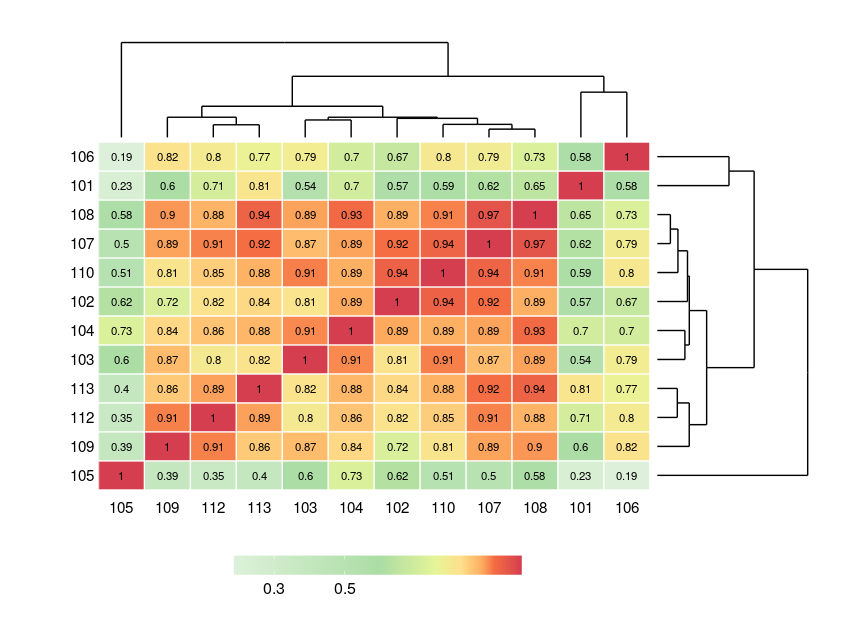

Genetic correlation between environments

**Genotypic Ranking**

- Identify superior genotypes for subsets of the testing environments.
- Crossover interaction across the environments

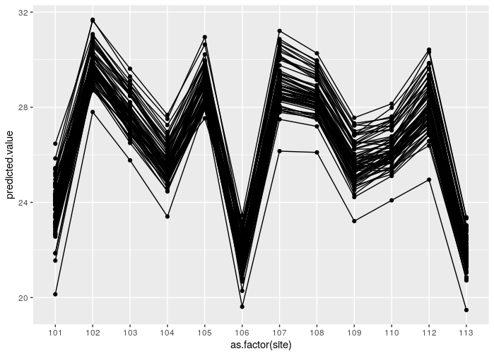

Genotypic ranking across the environments

**Heritability**

- Different flavors in the literature
- Can be computed per environment
- Generic form for the narrow-sense h2 as presented by [Isik et al., 2017](https://www.springer.com/gp/book/9783319551753) in the case of complex var-cov structures for the genetic and residual term

$$h^2 = \dfrac{4\bar{\sigma}_{gii'}}{\sigma^2_{gi} + \bar{\sigma}^2_{ei}} = \dfrac{4(0.563)}{0.77+7.12} =0.28$$

# 3 Final Considerations

- Analysis of a data set is an iterative process consisting of fitting and comparing alternative models to identify a good model for the data under study.
- When there are many environments, estimation of an unstructured covariance matrix can be infeasible.
- Recently, interest has focused on structures which utilise the leading principal components of a covariance matrix, as it has become understood that such structures can be fitted directly within the mixed model framework commonly employed for estimation and prediction in quantitative genetic analyses. This encompasses both reduced rank and **factor-analytic (FA) models** [(Meyer, 2009)](https://gsejournal.biomedcentral.com/articles/10.1186/1297-9686-41-21)

# 4 References

**Books**

- Isik et al., 2017. Genetic Data Analysis for Plant and Animal Breeding. [Book link](https://www.springer.com/gp/book/9783319551753)
- Falconer and Mackay, 1996. Introduction to Quantitative Genetics. [Book link](https://www.amazon.com/Introduction-Quantitative-Genetics-Douglas-Falconer/dp/0582243025)

**Papers**

- Eeuwijk et al., 2016. What should students in plant breeding know about the statistical aspects of genotype × Environment interactions?. Crop Science. [Link for the paper](https://library.wur.nl/WebQuery/wurpubs/507495)
- Finaly and Wilkinson, 1963. The analysis of adaptation in a plant breeding programme. Australian Journal of Agricultural Research. [Link for the paper](https://www.publish.csiro.au/cp/ar9630742)
- Li and de los Campos, 2016. FW: An R Package for Finlay–Wilkinson Regression that Incorporates Genomic/Pedigree Information and Covariance Structures Between Environments. G3. [Link for the paper](https://www.g3journal.org/content/6/3/589)
- Malosetti et al., 2013. The statistical analysis of multi-environment data: modeling genotype-by-environment interaction and its genetic basis. Frontiers in Physiology. [Link for the paper](https://www.ncbi.nlm.nih.gov/pmc/articles/PMC3594989/)
- Meyer, 2009. Factor-analytic models for genotype × environment type problems and structured covariance matrices. Genetics Selection Evolution. [Link for the paper](https://gsejournal.biomedcentral.com/articles/10.1186/1297-9686-41-21)
- Smith et al, 2005. The analysis of crop cultivar breeding and evaluation trials : an overview of current mixed model approaches. Link for the paper